# Results from the 2022 Composition Count Survey of the Chisana Caribou Herd in Wrangell - St. Elias National Park and Preserve, Alaska

Scott D. Miller

2023-11-29

Scott D. Miller  
Information Technology Specialist/Data Manager  
National Park Service, Arctic Inventory and Monitoring Network  
240 W. 5th Ave.  
Anchorage, AK 99501

Kyle Cutting  
Wildlife Biologist  
National Park Service, Wrangell - St. Elias National Park and Preserve  
8 Richardson Hwy Mile 106  
Copper Center, AK 99573

# Introduction

Caribou are an integral component of the ecosystem in Wrangell - St. Elias National Park and Preserve (WRST) and are of great importance to the ecosystem and to people for both consumptive and non-consumptive uses. WRST is mandated by the Alaska National Interest Lands Conservation Act to protect habitat for caribou, to provide the opportunity for continued subsistence uses, and to conserve natural and healthy wildlife populations. In order to meet these requirements the Park monitors the Chisana caribou herd with the goal of providing Park managers with reliable scientific information on the herd’s abundance, composition and distribution. WRST conducted a herd composition survey from 2022-10-14 to 2022-10-14 to assess calf recruitment, adult sex ratios, and seasonal distribution. In this report we provide provisional survey results in the form of data and summary statistics, but leave in-depth statistical analysis of population size and composition for a later date.

# Methods

Monitoring of caribou populations in CAKN employs the use of radiocollars and radiotelemetry to locate groups and to provide a mark/recapture estimate of population size and age and sex composition. The use of radiotelemetry is standard throughout Alaska and parts of Canada for monitoring caribou populations. A sample of 30-40 radiocollared cows is maintained for population assessment. Population assessment is made in two efforts: a post-calving (June) census, when cows are grouped and calf production can be determined; and a fall composition count when bulls associate with cows during the rut. With the mark-recapture estimate of cows from the spring survey and the herd composition obtained from the fall count, the herd size, composition, and calf recruitment can be estimated. Both annual surveys are conducted by aerial observation from a helicopter and small airplane. These caribou monitoring methods were formalized in a collaboration between the WRST and the Central Alaska Inventory and Monitoring Program in 2018 (Putera and Miller, 2018). The WRST caribou monitoring protocol, and standard operating procedures, as well as reports, journal articles and data are available through the NPS’s Integrated Resource Management Applications portal at https://irma.nps.gov/DataStore/Reference/Profile/2217176.

# Results

Table 1. Survey dates and observer/pilot pairs, 2022.

| Date | SearchArea | Observer | Pilot |
| --- | --- | --- | --- |
| 2022-10-14 | AK |  |  |
| 2022-10-14 | YG | Wall, C. (YT), Combs | Fox, A (YT) |

## Herd distribution

Caribou were distributed as shown in Figure 1.

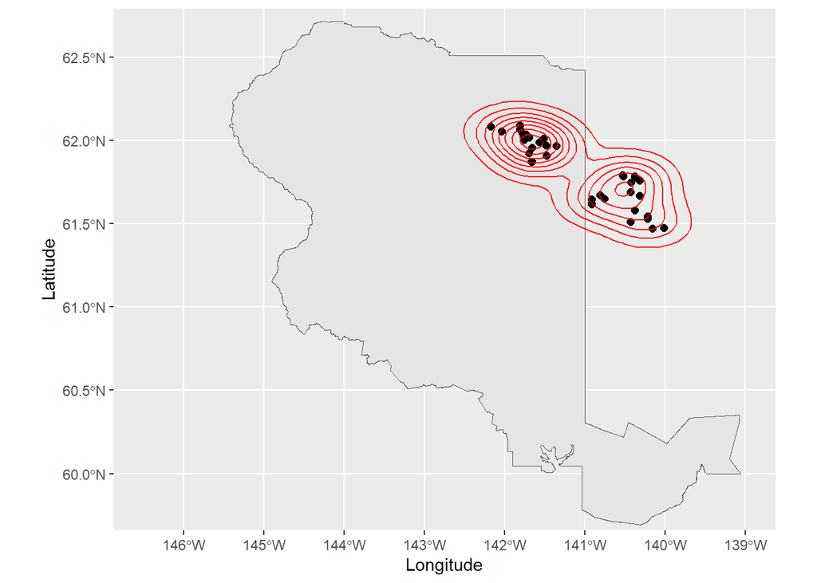

Figure 1. Distribution and density of caribou groups in Wrangell - St. Elias National Park and Preserve and outlying areas during the 2022 Fall Chisana Caribou Composition Survey.

## Herd Composition

We classified 540 caribou during the survey. Calf recruitment was 20.8 per 100 cows and there were 51.1 bulls per 100 cows (Table 1).

Table 1. Composition survey results.

|  | 1 |
| --- | --- |
| Survey name | 2022 Fall Chisana Caribou Composition Survey |
| Year | 2022 |
| Herd | Chisana |
| Survey type | CC |
| Type of survey | Composition count |
| Cow | 313 |
| Calf | 65 |
| Small bull | 78 |
| Medium bull |  |
| Large bull | 82 |
| Bull | 160 |
| Adult | 473 |
| Caribou | 540 |
| Unknown | 2 |
| Calf, male |  |
| Calf, female |  |
| Calf, unclassified |  |
| GroupSize_Mean | 13.85 |
| Pct. calves | 12 |
| Pct. cows | 58 |
| Pct. bull | 29.6 |
| Calves/100 cows | 20.8 |
| Bulls/100 cows | 51.1 |
| Total groups observed | 39 |
| Groups in the survey area |  |
| Groups out of the survey area |  |
| Marked groups | 20 |
| Marked groups seen | 17 |
| Marked groups not seen | 3 |
| Percent marked groups seen | 85 |
| Percent marked groups not seen | 15 |
| Total collared animals observed | 42 |
| Number of frequencies that were available on survey date (Animal_Movement) | 46 |
| Collars not heard or not searched | 4 |
| Total groups marked seen | 36 |
| Start date | 2022-10-14 |
| End date | 2022-10-14 |
| Survey days | 1 |
| Search areas | 2 |
| Season | Fall |
| CertificationLevel | Provisional |

## Historical Results

### Counts

Table 2. Historical composition of the Chisana herd.

| Year | Survey type | Cow | Calf | Small bull | Medium bull | Large bull | Bull | Adult | Caribou | Unknown | n | Qual. |
| --- | --- | --- | --- | --- | --- | --- | --- | --- | --- | --- | --- | --- |
| 2021 | CC | 263 | 31 | 57 |  | 62 | 119 | 382 | 413 |  | 29 | * |
| 2019 | CC | 279 | 47 | 40 | 38 | 41 | 119 | 398 | 445 |  | 22 | * |
| 2018 | CC | 243 | 32 | 25 | 25 | 45 | 95 | 338 | 370 |  | 28 | * |
| 2017 | CC | 348 | 73 | 34 | 30 | 48 | 112 | 460 | 533 |  | 36 | * |
| 2016 | CC | 388 | 106 | 78 | 30 | 79 | 187 | 575 | 681 |  | 55 | * |
| 2015 | CC | 252 | 46 | 21 | 58 | 22 | 101 | 353 | 399 |  | 28 | * |
| 2014 | CC | 323 | 75 | 29 | 34 | 67 | 130 | 453 | 528 |  | 36 | * |
| 2012 | CC | 115 | 23 | 40 |  | 35 | 75 | 190 | 213 |  | 13 | * |
| 2011 | CC | 472 | 87 | 69 | 56 | 70 | 195 | 667 | 754 |  | 49 | * |
| 2009 | CC | 308 | 47 | 47 | 48 | 55 | 150 | 458 | 505 |  | 37 | * |
| 2008 | CC | 324 | 67 | 45 | 45 | 51 | 141 | 465 | 532 |  | 38 | * |
| 2006 | CC | 371 | 79 | 60 | 59 | 59 | 178 | 549 | 628 |  | 62 | * |
| 2004 | CC | 334 | 69 | 51 |  | 76 | 127 | 461 | 530 |  | 36 | * |
| 2003 | CC | 90 | 20 | 9 | 29 | 0 | 38 | 128 | 148 |  | 12 | * |
| 2002 | CC |  | 33 |  |  |  | 0 | 0 | 33 |  | 19 | * |
| 2002 | CC | 186 | 25 | 13 | 11 | 23 | 47 | 233 | 258 |  | 16 | * |
| 2001 | CC | 281 | 11 | 27 | 15 | 22 | 64 | 345 | 356 |  | 18 | * |
| 2000 | CC | 328 | 20 | 33 | 16 | 15 | 64 | 392 | 412 |  | 16 | * |
| 1999 | CC |  | 23 |  |  |  | 0 | 0 | 23 |  | 14 | * |
| 1999 | CC | 256 | 18 | 25 | 7 | 12 | 44 | 300 | 318 |  | 14 | * |
| 1998 | CC | 188 | 8 | 17 | 5 | 13 | 35 | 223 | 231 |  | 13 | * |
| 1997 | CC |  | 13 |  |  |  | 0 | 0 | 13 |  | 16 | * |
| 1997 | CC | 376 | 52 | 3 | 63 | 26 | 92 | 468 | 520 |  | 19 | * |
| 1996 | CC |  | 9 |  |  |  | 0 | 0 | 9 |  | 9 | * |
| 1996 | CC | 607 | 29 | 36 | 30 | 30 | 96 | 703 | 732 |  | 18 | * |
| 1995 | CC |  | 34 |  |  |  | 0 | 0 | 34 |  | 19 | * |
| 1995 | CC | 432 | 19 | 28 | 21 | 43 | 92 | 524 | 543 |  | 25 | * |
| 1994 | CC |  | 37 |  |  |  | 0 | 0 | 37 |  | 14 | * |
| 1994 | CC | 393 | 42 | 22 | 48 | 38 | 108 | 501 | 543 |  | 22 | * |
| 1993 | CC | 633 | 13 | 49 | 74 | 37 | 160 | 793 | 806 |  | 31 | * |
| 1992 | CC |  | 10 |  |  |  | 0 | 0 | 10 |  | 9 | * |
| 1992 | CC | 870 | 1 | 91 | 117 | 63 | 271 | 1141 | 1142 |  | 33 | * |
| 1991 | CC |  | 22 |  |  |  | 0 | 0 | 22 |  | 47 | * |
| 1991 | CC | 605 | 8 | 110 | 101 | 31 | 242 | 847 | 855 |  | 47 | * |
| 1990 | CC | 590 | 61 | 85 | 130 | 0 | 215 | 805 | 866 |  | 50 | * |
| 1989 | CC | 0 | 47 | 14 | 24 | 0 | 38 | 38 | 619 | 534 | 47 | * |
| 1988 | CC | 585 | 183 | 58 | 95 | 54 | 207 | 792 | 975 |  | 79 | * |
| 1987 | CC | 456 | 126 | 94 | 47 | 37 | 178 | 634 | 760 |  | 1 | * |
| 1986 | CC | 288 | 94 | 24 | 64 | 37 | 125 | 413 | 507 |  | 54 | * |
| 1982 | CC | 261 | 54 | 32 | 18 | 43 | 93 | 354 | 408 |  | 24 | * |
| 1980 | CC | 391 | 85 | 1 | 7 | 63 | 71 | 462 | 548 | 1 | 53 | * |

Survey types: CC = Composition count, PE = Population estimate Qual.: * = Provisional data

### Composition

Table 3 and Figures 2 and 3 summarize historical sex and age ratios and herd composition statistics over time for the Chisana herd.

Table 3. Historical sex and age ratios and herd composition statistict for the Chisana herd.

| Year | Season | Survey type | Mean group size | Pct. calves | Pct. cows | Pct. bull | Calves/100 cows | Bulls/100 cows | n |
| --- | --- | --- | --- | --- | --- | --- | --- | --- | --- |
| 2021 | Fall | CC | 14.24 | 7.5 | 63.7 | 28.8 | 11.8 | 45.2 | 29 |
| 2019 | Fall | CC | 20.23 | 10.6 | 62.7 | 26.7 | 16.8 | 42.7 | 22 |
| 2018 | Fall | CC | 13.21 | 8.6 | 65.7 | 25.7 | 13.2 | 39.1 | 28 |
| 2017 | Fall | CC | 14.81 | 13.7 | 65.3 | 21.0 | 21.0 | 32.2 | 36 |
| 2016 | Fall | CC | 12.38 | 15.6 | 57.0 | 27.5 | 27.3 | 48.2 | 55 |
| 2015 | Fall | CC | 14.25 | 11.5 | 63.2 | 25.3 | 18.3 | 40.1 | 28 |
| 2014 | Fall | CC | 14.67 | 14.2 | 61.2 | 24.6 | 23.2 | 40.2 | 36 |
| 2013 | Fall | PE | 17.53 | 9.7 | 60.7 | 29.6 | 15.9 | 48.8 | 36 |
| 2012 | Fall | CC | 16.38 | 10.8 | 54.0 | 35.2 | 20.0 | 65.2 | 13 |
| 2011 | Fall | CC | 15.39 | 11.5 | 62.6 | 25.9 | 18.4 | 41.3 | 49 |
| 2010 | Fall | PE | 13.23 | 13.8 | 60.8 | 25.4 | 22.8 | 41.8 | 47 |
| 2009 | Fall | CC | 13.65 | 9.3 | 61.0 | 29.7 | 15.3 | 48.7 | 37 |
| 2008 | Fall | CC | 14.00 | 12.6 | 60.9 | 26.5 | 20.7 | 43.5 | 38 |
| 2007 | Fall | PE | 14.38 | 8.1 | 61.5 | 30.5 | 13.1 | 49.5 | 50 |
| 2006 | Fall | CC | 10.13 | 12.6 | 59.1 | 28.3 | 21.3 | 48.0 | 62 |
| 2005 | Fall | PE | 8.85 | 13.6 | 59.0 | 26.8 | 23.1 | 45.4 | 73 |
| 2004 | Fall | CC | 14.72 | 13.0 | 63.0 | 24.0 | 20.7 | 38.0 | 36 |
| 2003 | Fall | CC | 12.33 | 13.5 | 60.8 | 25.7 | 22.2 | 42.2 | 12 |
| 2003 | Fall | PE | 11.98 | 15.7 | 61.6 | 22.7 | 25.5 | 36.9 | 50 |
| 2002 | Fall | CC | 16.13 | 9.7 | 72.1 | 18.2 | 13.4 | 25.3 | 16 |
| 2002 | Spring | CC | 1.74 | 100.0 |  |  |  |  | 19 |
| 2001 | Fall | CC | 19.78 | 3.1 | 78.9 | 18.0 | 3.9 | 22.8 | 18 |
| 2000 | Fall | CC | 25.75 | 4.9 | 79.6 | 15.5 | 6.1 | 19.5 | 16 |
| 1999 | Fall | CC | 22.71 | 5.7 | 80.5 | 13.8 | 7.0 | 17.2 | 14 |
| 1999 | Spring | CC | 1.64 | 100.0 |  |  |  |  | 14 |
| 1998 | Fall | CC | 17.77 | 3.5 | 81.4 | 15.2 | 4.3 | 18.6 | 13 |
| 1997 | Fall | CC | 27.37 | 10.0 | 72.3 | 17.7 | 13.8 | 24.5 | 19 |
| 1997 | Spring | CC | 0.81 | 100.0 |  |  |  |  | 16 |
| 1996 | Fall | CC | 40.67 | 4.0 | 82.9 | 13.1 | 4.8 | 15.8 | 18 |
| 1996 | Spring | CC | 1.00 | 100.0 |  |  |  |  | 9 |
| 1995 | Fall | CC | 21.72 | 3.5 | 79.6 | 16.9 | 4.4 | 21.3 | 25 |
| 1995 | Spring | CC | 1.79 | 100.0 |  |  |  |  | 19 |
| 1994 | Fall | CC | 24.68 | 7.7 | 72.4 | 19.9 | 10.7 | 27.5 | 22 |
| 1994 | Spring | CC | 2.64 | 100.0 |  |  |  |  | 14 |
| 1993 | Fall | CC | 26.00 | 1.6 | 78.5 | 19.9 | 2.1 | 25.3 | 31 |
| 1993 | Spring | PE | 39.00 | 100.0 |  |  |  |  | 1 |
| 1992 | Fall | CC | 34.61 | 0.1 | 76.2 | 23.7 | 0.1 | 31.1 | 33 |
| 1992 | Spring | CC | 1.11 | 100.0 |  |  |  |  | 9 |
| 1991 | Fall | CC | 18.19 | 0.9 | 70.8 | 28.3 | 1.3 | 40.0 | 47 |
| 1991 | Spring | CC | 0.47 | 100.0 |  |  |  |  | 47 |
| 1990 | Fall | CC | 17.32 | 7.0 | 68.1 | 24.8 | 10.3 | 36.4 | 50 |
| 1989 | Fall | CC | 13.17 | 7.6 |  | 6.1 |  |  | 47 |
| 1989 | Fall | PE | 55.00 | 100.0 |  |  |  |  | 1 |
| 1989 | Spring | PE | 160.00 | 100.0 |  |  |  |  | 1 |
| 1988 | Fall | CC | 12.34 | 18.8 | 60.0 | 21.2 | 31.3 | 35.4 | 79 |
| 1987 | Fall | CC | 760.00 | 16.6 | 60.0 | 23.4 | 27.6 | 39.0 | 1 |
| 1987 | Spring | PE | 94.00 | 100.0 |  |  |  |  | 1 |
| 1986 | Fall | CC | 9.39 | 18.5 | 56.8 | 24.7 | 32.6 | 43.4 | 54 |
| 1982 | Fall | CC | 17.00 | 13.2 | 64.0 | 22.8 | 20.7 | 35.6 | 24 |
| 1980 | Fall | CC | 10.34 | 15.5 | 71.4 | 13.0 | 21.7 | 18.2 | 53 |

Figure 2. Calves/100 cows over time.

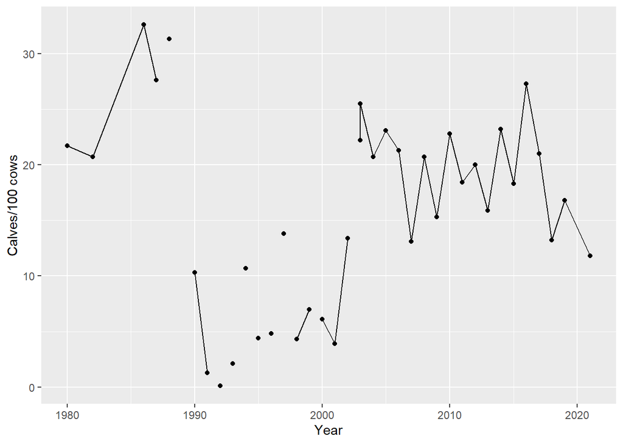

Figure 3. Bulls/100 cows over time.

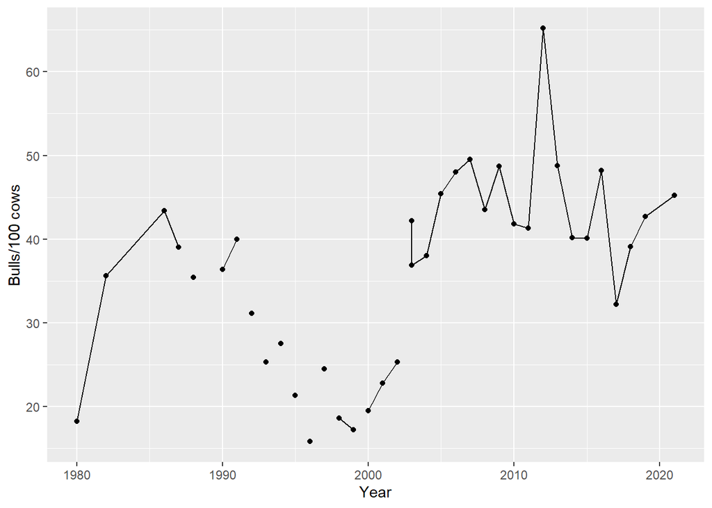

# Discussion

# References

ANILCA, 1980

# Appendix A: Dataset Certification Summary

Appendix A contains a summary of data quality certification levels and number of records for the 2022 Fall Chisana Caribou Composition Survey (current as of 2023-11-29). Definitions follow the summary table.

| SurveyName | CertificationLevel | Number of records |
| --- | --- | --- |
| 2022 Fall Chisana Caribou Composition Survey | Provisional | 39 |

[output not shown]

# Appendix B: Survey Description and Notes

Appendix B contains a description of the survey and any notes about the survey as written by the pilot, observer or biologist. These data are available in the WRST_Caribou.Surveys table.

## Survey Description

NA

## Survey Notes

(YG crew) Harley (fixed wing) could only stay for a little while due to mechanical issue, (but identified 13 collars on yukon side) we ran out of time to survey lower elevation forests and didn’t have time to pinpoint missed group and used Harleys group comp estimate. (Alaska crew) ideal survey conditions, good tracking, snow 40 cm, 1 day old, survey time 5 hrs, 40 mins. temp -21 at airport, -14 to -7 C at site, ice fog in valley in morning, 8 cm fresh snow at airport and 3 ft at Klutlan Plateau, maybe 1 ft and a half at Sergerent clear calm weather, 15F

# Appendix C: Data Quality Issues

Appendix C Contains known data quality issues that potential users of the dataset should know (current as of 2023-11-29).

| IsResolved | DateLogged | Author | Issue |
| --- | --- | --- | --- |
| 0 | 2023-11-27 13:42:48 | NPS | Group #28 has a Yukon visual collar W80 which does not correspond to an NPS collar and is blank in the dataset. |
| 1 | 2023-11-27 13:42:48 | NPS | Bull categories only included small and mature bulls - no medium bulls. This is typical of Yukon survey methods. |

# Appendix D: Quality Control Checks Results

Current as of 2023-11-29

Appendix D contains the results of quality control checks on the survey dataset. These results are intended to inform NPS scientists about any data quality problems and should be resolved, if possible, before publication.Move unresolvable issues that data consumers should know about to the Surveys_Issues table and publish from there.

## QC-1: Observed/Available Collars Reconciliation

Ideally, every collar that is registered in the NPS Animal Movement database for the Chisana monitoring program is searched for during a composition survey. Table 4 shows the count of frequencies detected during the 2022 Fall Chisana Caribou Composition Survey and the number of collars that were available according to the data in the Animal Movement database. It is not critical that the numbers match, only that they reconcile in a logical way. Collars occasionally fail, the terrain may block their signal, the crew ran out of time or encountered bad weather, or collars were are not detected for another reason. Sometimes collar deployments are not terminated in Animal_Movement after a mortality, resulting in an inflated inventory of available collars. The list below is a starting point for reconciling these issues.

Table 4. Observed/Available Collars Reconciliation.

| Survey | Observed collar frequencies | Available collar frequencies |
| --- | --- | --- |
| 2022 Fall Chisana Caribou Composition Survey | 42 | 46 |

## QC-2: Marked groups/frequency(ies) detected check

An important component of caribou surveys is sightability which is accomplished through a mark-recapture model. Groups are marked via GPS collars. The first survey flight does not have access to GPS telemetry from the collars and searches for caribou blind. The follow up flight is able to find marked groups via telemetry and tags each observed animal group as marked if it had at least one collared animal in it and the group is marked as ‘seen’ if the blind group found it. This quality control test shows records having a non-null FrequenciesInGroup attribute and its corresponding Marked attribute marked anything but 1.

Table 5. Records having non-null FrequenciesInGroup attribute with Marked attribute not equal to 1 (boolean, True). A blank table below indicates a QC check PASS.

| SurveyName | SightingDate | GroupNumber | Marked | FrequenciesInGroup |
| --- | --- | --- | --- | --- |

## QC-3: Missing sightability information

Quality control check QC-3 extends check QC-2 by providing information about how many survey records have null Seen and Marked attributes.

Table 6. Surveys where sightability data (completely null Seen and Marked attributes for all survey records) were not collected. A blank table below indicates a QC check PASS.

| Survey | Seen | Marked |
| --- | --- | --- |